# Forensic Glass: Heatmap and Hierarchical Clustering

efg, 2017-09-02

## Setup

```r
time.1 <- Sys.time()
```

Required packages

```r
library(MASS)         # fgl data
library(NMF)          # aheatmap
library(dplyr)        # select
library(doParallel)   # parallel processing:  registerDoParallel
library(pvclust)      # pvclust
```

Forensic Glass Data

```r
rawData <- fgl
rownames(rawData) <- make.names( as.character(rawData$type), unique=TRUE )  # unique rownames
rowLabel <- rawData["type"]   # data.frame with single column "type"
rawData  <- rawData %>% select(-type) %>% as.matrix()

# Mean=0, StdDev=1
centeredScaledData <- scale(rawData, center=TRUE, scale=TRUE)
```

## Heatmap

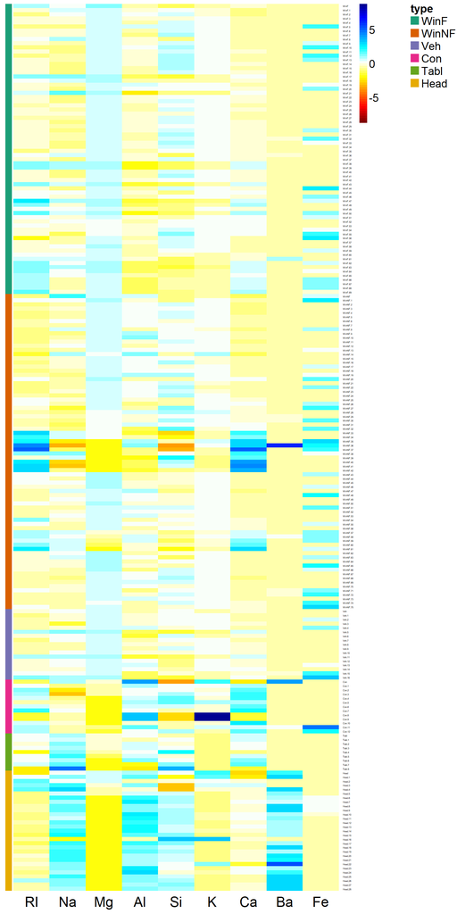

```r
colorScale <- colorRampPalette(c("#7F0000","red","#FF7F00","yellow","white",
                                 "cyan", "#007FFF", "blue","#00007F"))(100)

aheatmap(centeredScaledData, color=colorScale,       # Diverging Palette
         Rowv=NA, Colv=NA,                           # no re-ordering of data
         scale="col", breaks=0,                      # Palette centered on this value
         annRow=rowLabel, annColors="Dark2",         # Qualitative Palette (RColorBrewer)
         treeheight=c(100, 100),                     # size of dendrograms
         fontsize=14, cexCol=1.25,
         width=8, height=16)
```

## Clustering of Predictors and Instances

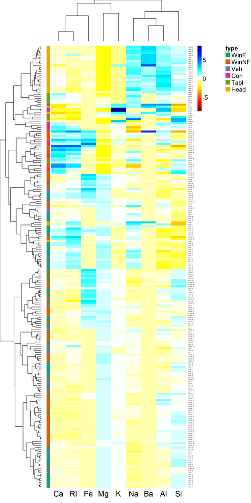

```r
aheatmap(centeredScaledData, color=colorScale,       # Diverging Palette
         scale="col", breaks=0,                      # Palette centered on this value
         annRow=rowLabel, annColors="Dark2",         # Qualitative Palette (RColorBrewer)
         distfun="pearson",                          # start wtih "pearson" or "euclidean"
         treeheight=c(100, 100),                     # size of dendrograms
         fontsize=14, cexCol=1.25,
         width=8, height=16)
```

This is a visual view of the problem. The vertical color bar at the left shows the glass type for the predictors to the right. What patterns of predictors can be observed for a given glass type?

There are many eqivalent ways to display the [dendrogram](https://en.wikipedia.org/wiki/Dendrogram) trees above. Any pair of nodes shown connected in the dendrogram can be flipped for an equivalent representation.

The “Head” type formed a tight cluster at the top, but other types do not appear in such tight clusters.

How reliable are the clusters of predictors shown in the dendrogram at the top?

### Evaluate Uncertainty in Clustering Predictors

There are many equivalent trees. How reliable are the branches of predictors if we look at many clusterings?

**pvclust** Algorithm

1. Generated thousands of bootstrap samples by randomly sampling elements of the data
2. Compute hierarchical clustering on each bootstrap copy
3. For each cluster:
- compute the **bootstrap probability (BP)** value which corresponds to the frequency that the cluster is identified in bootstrap copies.
- Compute the **approximately unbiased (AU)** probability values (p-values) by multiscale bootstrap resampling.

```r
rCluster <- makePSOCKcluster(6)   # use 6 cores
registerDoParallel(rCluster)
```

Use nboot=1000 for testing at first, and then use nboot=10000 for smaller error.

```r
pvResult <- pvclust(centeredScaledData,
                    parallel=TRUE,
                    method.hclust="ward.D2", method.dist="correlation",
                    nboot=10000, iseed=19937)
```

```
Creating a temporary cluster...done:
socket cluster with 7 nodes on host 'localhost'
Multiscale bootstrap... Done.
```

```r
stopCluster(rCluster)
```

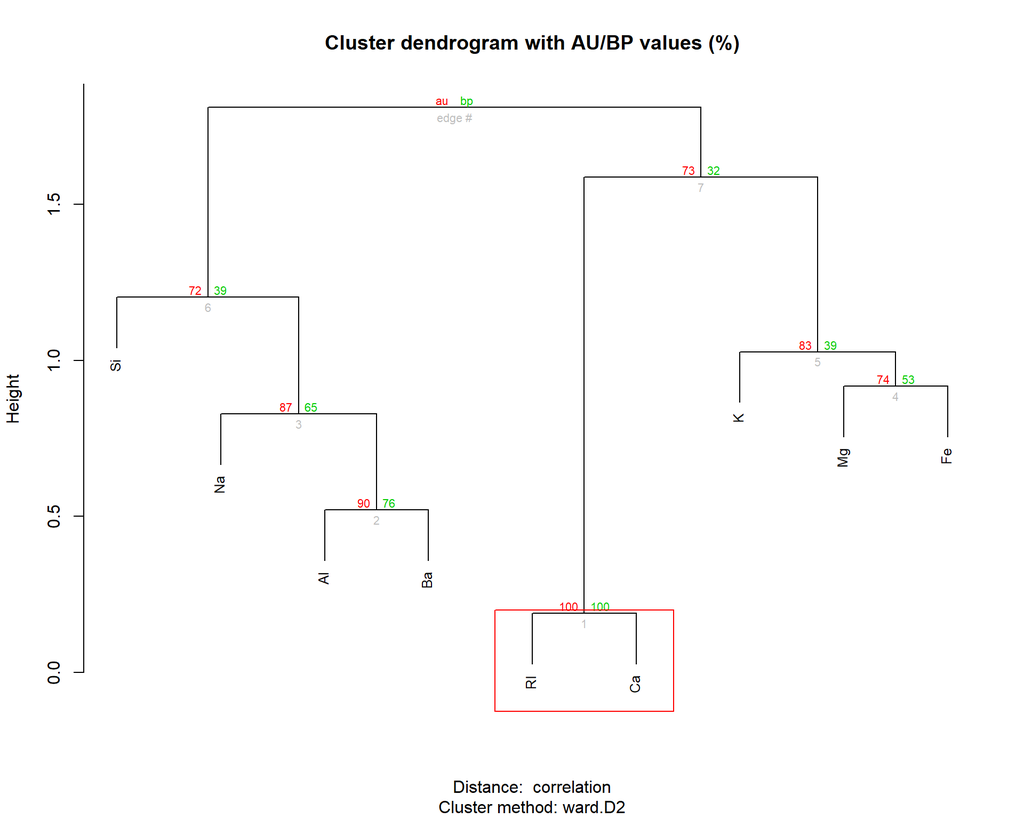

```r
plot(pvResult, cex=0.8, cex.pv=0.7)
pvrect(pvResult, alpha=0.95)
```

**Clusters with AU > = 95% are considered to be strongly supported by data.**

*For a cluster with AU p-value > 0.95, the hypothesis that “the cluster does not exist” is rejected with significance level 0.05.*

```r
pvResult
```

```
Cluster method: ward.D2
Distance      : correlation

Estimates on edges:

     au    bp se.au se.bp      v     c  pchi
1 1.000 1.000 0.000 0.000  0.000 0.000 0.000
2 0.902 0.758 0.005 0.001 -0.995 0.295 0.147
3 0.871 0.652 0.005 0.002 -0.761 0.370 0.002
4 0.741 0.525 0.008 0.002 -0.355 0.292 0.464
5 0.834 0.391 0.006 0.002 -0.348 0.624 0.000
6 0.720 0.390 0.008 0.002 -0.152 0.431 0.024
7 0.728 0.319 0.009 0.002 -0.069 0.539 0.101
8 1.000 1.000 0.000 0.000  0.000 0.000 0.000
```

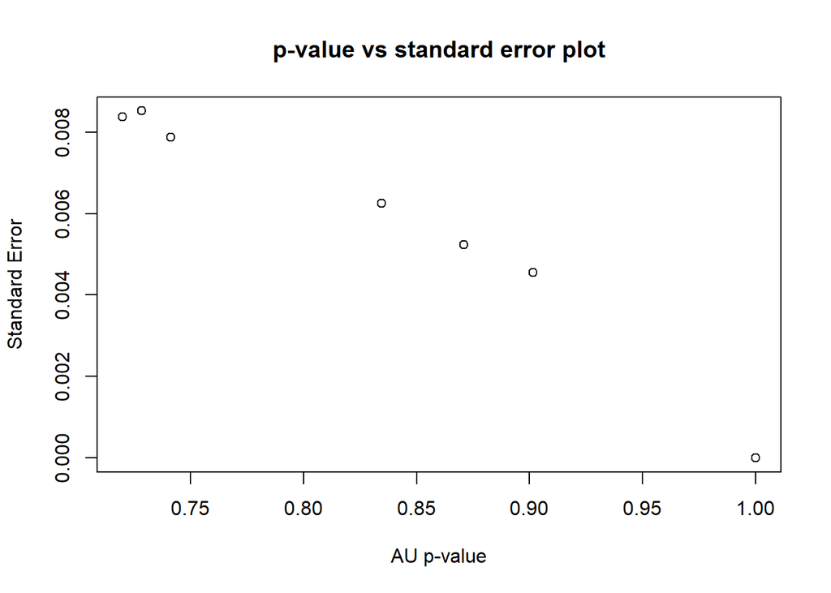

```r
seplot(pvResult)
```

Investigate any clusters with extremely large standard errors.

Processing time: 24.1 sec

2017-09-04 10:46:28

## References

- [NMF: Algorithms and Framework for Nonnegative Matrix Factorization (NMF)](https://cran.r-project.org/web/packages/NMF/index.html), CRAN.
- [Generating heatmaps for Nonnegative Matrix Factorization](https://cran.r-project.org/web/packages/NMF/vignettes/heatmaps.pdf), CRAN.
- [Pvclust: an R package for assessing the uncertainty in hierarchical clustering](https://www.ncbi.nlm.nih.gov/pubmed/16595560), *Bioinformatics*, 2006.
- [pvclust: An R package for hierarchical clustering with p-values](http://stat.sys.i.kyoto-u.ac.jp/prog/pvclust/), Ryota Suzuki and Hidetoshi Shimodaira.